# Tsublightint_growth_Maize

Author

Katja Holzhauser, Agronomy and Crop Science Group, Kiel University

Published

September 7, 2026

Module for dry matter production of silage maize. Authors: Katja Holzhauser, Josephine Bukowiecki, Babette Wienforth, Henning Kage & Crop Science and Agronomy Group, Kiel University Last edited: 14.08.2026 Parts of the module are published in: References: Holzhauser, K., Wienforth, B.M., Komainda, M., Herrmann, A., Zimmermann, I. & Dippold, M.A. et al. (2026) HUME-Maize: modelling silage maize yield formation across genotypes and scales. The Journal of Agricultural Science, 164, e34. Available from: https://doi.org/10.1017/S0021859626100719. Holzhauser, K. (2025) Cover Crops for Sustainable Silage-Maize Production: Enhancing Resource Use Efficiency through Modelling and Remote Sensing (Doctoral dissertation). Christian-Albrechts-Universität zu Kiel: Kiel Available from: https://macau.uni-kiel.de/receive/macau_mods_00006346. Wienforth, B. (2011) Cropping systems for biomethane production: a simulation based analysis of yield, yield potential and resource use efficiency (Doctoral dissertation). Christian-Albrechts-Universität zu Kiel

# 1 Descendence

The class Tsublightint_growth_Maize has the following ancestor classes shown in Table 1.

Table 1: Ancestor classes of Tsublightint_growth_Maize

| AncestorClass | Namespace |
| --- | --- |
| TSubmodel | UMod |
| TGraphicControl | Vcl.Controls |
| TControl | Vcl.Controls |
| TComponent | System.Classes |
| TPersistent | System.Classes |
| TObject | System |

TRUE

# 2 Scientific Background

## 2.1 Modelling DM production

Within the season, daily dry matter production ($\frac{dDM_{tot}}{dt}$) is driven by absorbed photosynthetically active radiation ($Q$, MJ m<sup>-2</sup> d<sup>-1</sup>) and potential light-use efficiency (LUE, g MJ<sup>-1</sup> PAR<sup>-1</sup>):

$$\frac{{\mathrm{dDM}}_{\mathrm{total}}}{\mathrm{dt}}\mathrm{=Q*}LUE * Temp_{fact} * SWDF \tag{1}$$

With $Temp_{\text{fact}}$, a temperature weight factor for photosynthetic activity [-], ranging between 0 to 1 and calculated with a trapezoidal function (Marshall and Squire (1996); Porter et al. (1999)) and the soil water deficit factor (SWDF).

$$Temp_{fact} = \begin{cases}
0 & \text{if } TMPM < C_1 \\
\frac{TMPM - C_1}{C_2 - C_1} & \text{if } C_1 \leq TMPM \leq C_2 \\
1 & \text{if } C_2 < T_{mean} \leq C_3 \\
\frac{C_4 - TMPM}{C_4 - C_3} & \text{if } C_3 < TMPM \leq C_4 \\
0 & \text{if } TMPM > C_4
\end{cases} \tag{2}$$

The Q is calculated according to the Beer-Lambert law (Monsi and Saeki (1953)), using the photosynthetically active radiation (PAR, MJ m<sup>-2</sup> d<sup>-1</sup>) and green area index (GAI, m<sup>2</sup> m<sup>-2</sup>) as input variable. Thereby, utilised PAR is an approximation, as it is commonly referred to as half of global radiation (GR, MJ m<sup>-2</sup> d<sup>-1</sup>, Szeicz (1974)):

$$\mathrm{Q\ =\ PAR*}\left(\mathrm{1-}\mathrm{e}^{{\mathrm{-k}}_{\mathrm{PAR}}\mathrm{*GAI} }\right) \tag{3}$$

$${\mathrm{LUE}}\mathrm{=}LUE_{max} - LUE_{steig}*PAR \tag{4}$$

with $LUE_{\text{max}}$ [-] and $LUE_{\text{steig}}$ [-] as regression parameters, which were optimized by the model internal Levenberg-Marquardt algorithm. In case of drought stress, LUE is reduced by the SWDF [-], originally proposed in a peanut growth model (Ferreyra et al. (2003)), describing the effects of water stress as non-linear function. This formulation allows for a more gradual decline in LUE under moderate stress and a stronger limitation under severe drought conditions, which was not accounted in another maize model.

$$SWDF = \min\left(1, 1 - \left(1 - \frac{Act_{trans}}{Pot_{trans}}\right)^{SWDF_{fact}}\right) \tag{5}$$

with the ratio between actual transpiration ($Act_{\text{trans}}$, mm d<sup>-1</sup>) and potential transpiration ($Pot_{\text{trans}}$ mm d<sup>-1</sup>) and a power value $SWDF_{\text{fact}}$ [-] describing the non-linear relation of SWDF. The parameter $SWDF_{\text{fact}}$ was set to 1.6 after model internal optimisation.

## 2.2 Results of calibration and evaluations

With the calibration dataset, a strong fit was achieved for whole-season $DM_{\text{shoot}}$ (R² = 0.97, Table 2) including measurement data of the whole season (n=83). The productivity on sandy loam sites was underestimated in 2008 and overestimated in 2007. However, predictions for the sandy site were accurate for both calibration years (Fig. 1 A). In the evaluation, prediction accuracy of $DM_{\text{shoot}}$ was still high with R² of 0.95 and a RMSE of 239.28 g m-2 (Table 2). In 2021, high yields harvested at both sandy loam and sandy sites were underestimated by the model. Due to severe drought stress at the sandy and sandy silt site in 2022, harvest was conducted one month earlier (2022/09/06 and 2022/09/02, respectively), explaining the low yields (Fig. 1 B).

Table 2: Results of model evaluation and calibration (in brackets) for aboveground dry matter production ($DM_{\text{shoot}}$). Performance was assessed with slope and intercept of the regression between measured and simulated data, R² and root mean square error (RMSE). n is the number of measurements.

| Variable | Einheit | Steigung (Slope) | Achsenabschnitt (Intercept) | R² | n | RMSE |
| --- | --- | --- | --- | --- | --- | --- |
| $\mathrm{DM}_{\mathrm{shoot}}$ | [g m⁻²] | 1.14 (1.08) | -102.91 (-73.91) | 0.95 (0.97) | 63 (83) | 239.28 (157.41) |

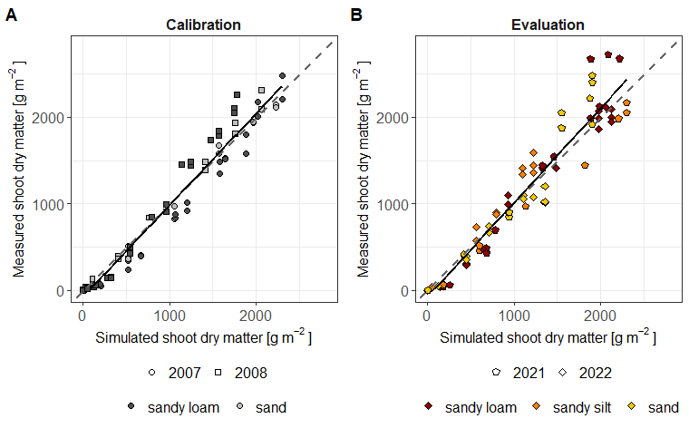

Figure 1: Dry matter estimation in calibration (grey) and evaluation (colourful) exhibit by simulated shoot dry matter g m<sup>-2</sup> against measured data of the evaluation datasets (7-12). Dashed line is the 1:1 line. Solid line is the regression between measured and simulated shoot dry matter g m<sup>-2</sup>.

### 2.2.1 Large scale evaluation

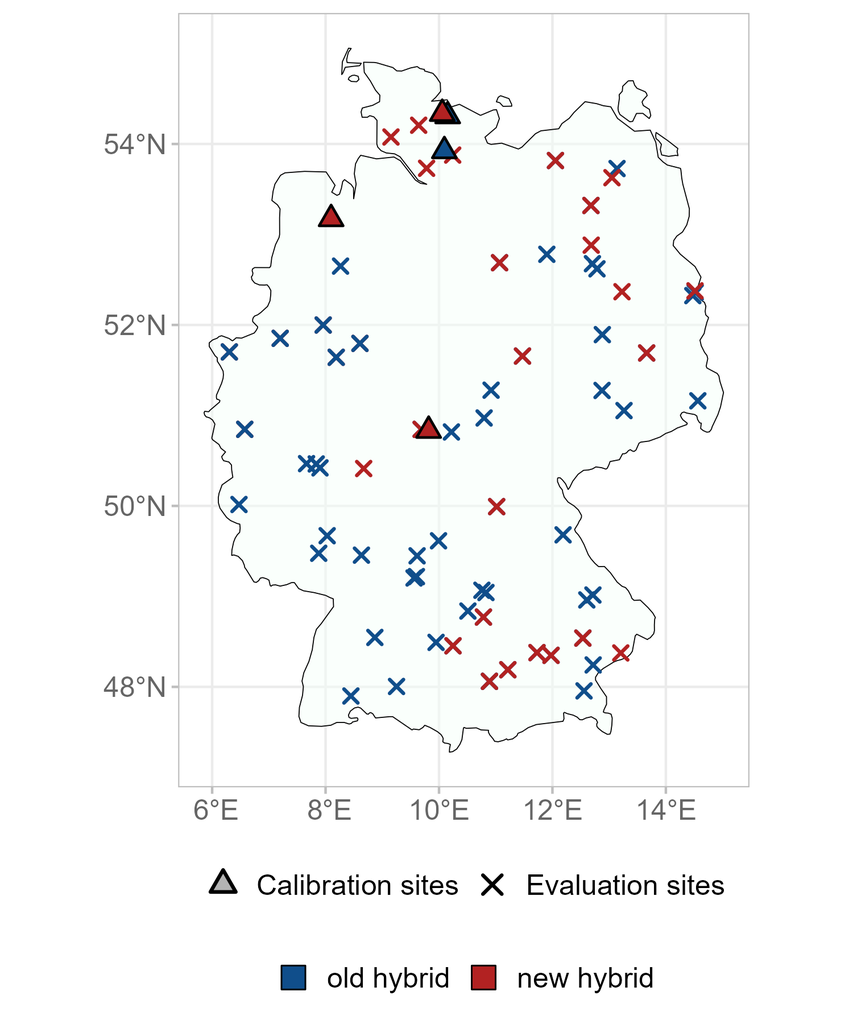

The large-scale evaluation for the prediction of final silage maize yields of the baseline-model resulted in a prediction error rRMSE of 0.16 and 0.24, for the older and the newer hybrid, respectively (Fig. 3 A). Overall d-statistic was 0.61, with a 0.62 for the old and 0.60 for the new hybrid. By the hybrid-specific parameterisation, the rRMSE for the newer hybrid was reduced to 0.21 and the d-statistic to 0.69. The comprehensive dataset enabled a further residual analysis of parameters affecting yield prediction accuracy. Thereby, a significant influence of drought stress was detected, which is computed by fSWDF (Eq. 5), with yields being tendentially underestimated. Without drought stress, the residuals declined below 0 (Fig. 3 B).

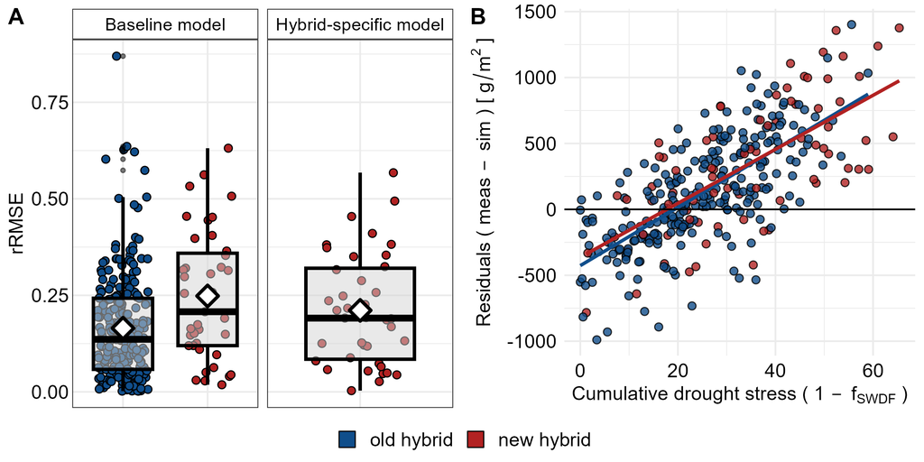

Figure 3: Large-scale evaluation of the HUME-Maize model approaches, utilising 287 datapoints of final silage maize yields across Germany from 2006-2021. Diamond depicts the mean of relative root mean square error (rRMSE). B: Residual analysis of the hybrid-specific model for both, old and new hybrids, showing the residuals (measured-simulated) across cumulative drought stress, which is the sum of (1-SWDF) throughout the season.

# 3 Submodel objects

Dynamic system model consists according to the Forrester approach of state variable, parameters, variables and external driving forces. This is implemented in Hume by dynamic lists, which contents is given in the following sections.

## 3.1 State variables

The class Tsublightint_growth_Maize has 6 following state variable(s).

Table 3: Initial Values of State Variables

| State variable | Units | Initial Value | Description |
| --- | --- | --- | --- |
| cumPAR_Trans_days |  | 0 |  |
| pot_Trans_GlobRad |  | 0 |  |
| Qsum | [MJ/m²] | 0 | Cumulative intercepted PAR (used for external LUE calculation) |
| QsumTempf_SWDF | [MJ/m²] | 0 | Cumulative intercepted PAR corrected for temperature and water stress (used for external LUE calculation) |
| TotDM | [g/m²] | 0 | Cumulative total dry matter accumulation |
| Trans_days |  | 0 |  |

TRUE

## 3.2 Parameters

The class Tsublightint_growth_Maize has 13 following parameter(s).

Table 4: Parameter values, units and descriptions

| Parameter | Units | Value | Description |
| --- | --- | --- | --- |
| alpha_TUE |  | 10.3000 | Parameter for TUE_vpd |
| beta_TUE |  | 0.4200 | Parameter for TUE_vpd |
| consLUE | [g/MJ] | 3.6000 | Constant light use efficiency (option: constant) |
| Ct1 | °C | 6.0000 | Minimum cardinal temperature for growth (Ct1) |
| Ct2 | °C | 16.0000 | Optimum temperature for growth (Ct2) |
| Ct3 | °C | 28.0000 | Maximum temperature for growth (Ct3) |
| Ct4 | °C | 34.0000 | Upper lethal temperature (Ct4) |
| LUE0 | [g/MJ] | 5.3596 | Baseline light use efficiency at zero radiation (Ritchie approach), option: exponential LUE |
| LUEexp | [unitless] | -0.0221 | Exponent in light conversion equation (Ritchie approach), option: exponential LUE |
| LUEmax | [g/MJ] | 4.9000 | Maximum potential light use efficiency (upper limit), (option: linear LUE) |
| LUEsteig | [unitless] | -0.1348 | Slope parameter for LUE decline with increasing radiation (option: linear LUE) |
| SWDF_fact | [unitless] | 1.6000 | Potenzfaktor zur nichtlinearen Beschreibung des Zusammenhangs zwischen TransRatio und SWDF |
| TRcrit |  | 1.0000 |  |

TRUE

## 3.3 Variables

The class Tsublightint_growth_Maize has 12 following variable(s).

Table 5: Variables, Units and Descriptions

Variable

Units

Description

avg_pot_Trans_GlobRad

fInt

[unitless]

Fraction of intercepted photosynthetically active radiation (PAR) (not used in model)

IntPar

[MJ/m²/d]

Intercepted PAR (daily total)

LUE

[g/MJ]

Light use efficiency (actual biomass production per unit intercepted PAR)

LUETempf_SWDF

[g/MJ]

Light use efficiency corrected for temperature and water deficit (effective LUE)

LUETempfact

[g/MJ]

Light use efficiency corrected for temperature (without drought stress)

SWDF

[unitless]

Soil water deficit factor (1 = no stress, 0 = severe stress)

Tempfact

[unitless]

Temperature factor for growth (0–1, Trapezoidal function)

TotTMgRate

[g/m²/d]

Total dry matter growth rate (actual)

TotTMgRate_TUE

[g/m²/d]

Total dry matter growth rate calculated via TUE

Trans_daysGR

TUE_vpd

[g/kg]

Transpiration use efficiency based on vapor pressure deficit (TUE_vpd = alpha * Sat_def^-beta)

TRUE

3.4 External variables

The class Tsublightint_growth_Maize has 13 following external variable(s).

(a) External Variables

| External Variable | Units | Description | Source |
| --- | --- | --- | --- |
| ActTrans |  | Actual transpiration rate | SoilNitrogenUp1 |
| ExtPAR_varLAI |  | Variable extinction coefficient for PAR (based on LAIgreen) | [subpartitioning_Maize_Roots_N1] |
| GlobRad | [W/m2] | Global radiation (incoming solar radiation) | Q:_TMPM_KD_06_09.txt |
| IStage |  | Integer scaled development stage | [subDevelopment_Maize1] |
| LAI |  | Leaf Area Index (green, used for light interception) | [subpartitioning_Maize_Roots_N1] |
| NNI |  | Nitrogen Nutrition Index (NNI = Nactual / Ncritical) | subpartitioning_Maize_Roots_N1 |
| potTrans |  | Potential transpiration rate | PenMonteith1 |
| Rad_Int | [mbar] | Intercepted radiation (PAR) | Q:_TMPM_KD_06_09.txt |
| Sat_def | [mbar] | Saturation deficit (vapor pressure deficit) | Q:_TMPM_KD_06_09.txt |
| Tbase6 |  | Base temperature for development (Tbase6) | [subDevelopment_Maize1] |
| TMPM | [Grad | Daily mean air temperature | Q:_TMPM_KD_06_09.txt |
| TransRatio |  | Ratio of actual to potential transpiration (0–1) | SoilNitrogenUp1 |
| XStage |  | Development stage (0–5), numeric scale | [subDevelopment_Maize1] |

TRUE

3.5 Options

The class Tsublightint_growth_Maize has 4 following option(s).

(b) Options and Descriptions

| Option | Selection | Description |
| --- | --- | --- |
| ContOutput | true | Output every time step? |
| DMCalcMethod | linlue_f_rad | ConstLUE: constant potential LUE |
| FinalOutput | false | Output of final values in separate file? |
| optDroughtimpact | droughtimpact | Drought impact by activating SWDF |

TRUE

## References

Bundesanstalt für Geowissenschaften und Rohstoffe, 2025. [Bodenübersichtskarte (BÜK200)](https://geoportal.bgr.de/mapapps/resources/apps/geoportal/index.html?lang=de#/geoviewer?metadataId=0f71e68f-8c83-4371-8842-1a26abed1854).

Ferreyra, R.A., Dardanelli, J.L., Pachepsky, L.B., Collino, D.J., Faustinelli, P.C., Giambastiani, G., Reddy, V.R., Jones, J.W., 2003. Nonlinear effects of water stress on peanut photosynthesis at crop and leaf scales. Ecological Modelling 168, 57–76. https://doi.org/10.1016/s0304-3800(03)00195-9

Kage, H., Alt, C., Stützel, H., 2001a. Predicting dry matter production of cauliflower (brassica oleracea l. Botrytis) under unstressed conditions. I. Photosynthetic parameters of cauliflower leaves and their implications for calculations of dry matter production. Scientia Horticulturae 87, 155–170.

Kage, H., Stutzel, H., Alt, C., 2001b. Predicting dry matter production of cauliflower (brassica oleracea l. Botrytis) under unstressed conditions - part II. Comparison of light use efficiency and photosynthesis-respiration based modules. Scientia Horticulturae 87, 171–190. https://doi.org/10.1016/s0304-4238(00)00180-1

Marshall, B., Squire, G.R., 1996. Non-linearity in rate-temperature relations of germination in oilseed rape. Journal of Experimental Botany 47, 1369–1375. https://doi.org/10.1093/jxb/47.9.1369

Monsi, M., Saeki, T., 1953. Über den lichtfaktor in den pflanzengesellschaften und seine bedeutung für die stoffproduktion. Japan.J.Bot. 14, 22–52.

Porter, C.H., Braga, R., Jones, J.W., 1999. An approach for modular crop model development.

Rose, M., Pahlmann, I., Kage, H., 2023. Modified crop rotations for a sustainable intensification? A case study in a high-yielding environment with recurrent nitrogen surplus. European Journal of Agronomy 142, 126644. https://doi.org/10.1016/j.eja.2022.126644

Szeicz, G., 1974. Solar radiation for plant growth. Journal of applied Ecology 11, 617–636.